# Vocab, readings: Week 7, 8, and some of week 9 lectures on Stats and Studies

This document may be updated as the lectures proceed.

For the words on this page that are underlined with tiny dots, a short definition will pop up if you hover over the word with your mouse pointer. Here’s an example: Alex. To study, first ask yourself on what the word means, and then check whether you’re right by hovering over the word.

## Important Readings

- [Planet Money podcast](https://www.npr.org/transcripts/178635250) on causation and correlation. Study questions:
  - Why did women take hormone replacement therapy?
  - What kind of study was done to better assess the effect of hormone replacement therapy?
    - Why was this study better than the first evidence that led hormone replacement therapy to originally start?
- [Khan Academy](https://www.khanacademy.org/math/probability/scatterplots-a1/creating-interpreting-scatterplots/v/correlation-and-causality) on correlation and causality. Study questions:
  - Khan talks about an article that suggests that eating breakfast prevents obesity. He also suggests alternative causal models. Name one.
- [Alex on the ways the word “control” is used](https://alexholcombe.github.io/teachingATHK/readings/controllingForVsControl.html) and random assignment.
- Another [explanation of random assignment](http://isps.yale.edu/node/16697).
- [What is a confounding variable?](http://www.statisticshowto.com/design-of-experiments/confounding-variable/)

# Vocabulary (partial list, see more terms on the [Lectures outline](https://alexholcombe.github.io/teachingATHK/outline.html))

- Causation. Know common words in English that are used to indicate causation.
- Correlation, used in this class to refer only to linear correlation.
- Post hoc ergo propter hoc
  - Social media usage exploded, then teenagers became more depressed. [Post hoc ergo propter hoc?](https://www.theguardian.com/books/2024/apr/27/anxious-generation-jonathan-haidt)
- Linear growth (black) versus exponential growth (blue).

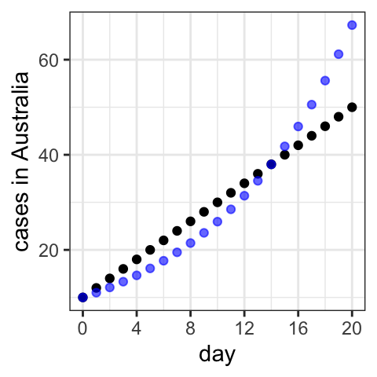

- Observational study Observational studies are sometimes referred to as correlational studies.
- Experiment
- Quasi / natural experiment
- Random assignment ([explainer](http://isps.yale.edu/node/16697))
- r

### Variables

- IV, DV
- “the intervention” refers to the independent variable
- “outcome variable” is another term for dependent variable
- Explanatory variable
- Extraneous variable
- Confound or confounding variables
- [Nuisance variable](https://dictionary.apa.org/nuisance-variable) or noise variable versus confound
- Omitted variable
- “Controlling for” a variable. Explained [here](https://alexholcombe.wordpress.com/2016/02/03/problems-with-controlling-for-variables-quick-notes/), in more detail than you need to know.
- Controlled variable

### Other terms

- Spurious correlation
- Causal model
- The [third-cause fallacy](https://apologetics.fandom.com/wiki/Third-cause_fallacy)
- Contingency table
- Residual
- Nonlinear model
- False positive, true positive, false negative, true negative
- Specificity and sensitivity

## Not-so-important Readings

- [Why is nutrition so hard to study?](https://www.medicalnewstoday.com/articles/why-is-nutrition-so-hard-to-study)
- Chapter 4, Correlation, of *Naked Statistics* (already recommended by Bruce)
- To understand how regression can “control for” an extraneous variable, read *Naked Statistics* Chapter 11 and the “Highly correlated explanatory variables” in Ch.12.
- [r-squared](http://blog.minitab.com/blog/adventures-in-statistics/regression-analysis-how-do-i-interpret-r-squared-and-assess-the-goodness-of-fit)
- https://alexholcombe.wordpress.com/2016/02/03/problems-with-controlling-for-variables-quick-notes/ The first few paragraphs are helpful for explaining “controlling for”, but then it quickly becomes more complex and more advanced than is needed for this unit.
- TEDxDHFastStream - Dr Ben Goldacre talking about [randomised controlled trials for public policy](https://www.youtube.com/watch?v=RzRs7cPrrfE)